# Team

- **Tommaso Giordano**,
- **Guido Gonnella**,
- **Andrea Migliorini**,
- **Simone Oggioni**,
- **Luca Olivieri**.

**Video**: https://drive.google.com/file/d/1PacfOhmIsuAtYV4P8HEvrRlB0yHz85rb/view?usp=share_link

# 2.0 Clustering

In this part we will apply **clustering** algorithms on top of vectorial representations (both sparse and dense) to perform some unsupervised analysis. We will deploy two algorithms:

1. `k-means`.
2. `DBSCAN`.

We will perform some validation on them (especially for the selection of $k$ in k-means), to pick the best setting for both, and then we will select the best overall setting and perform some analysis of the selected results.

## Why we use UMAP

To visualise the the clusters, we will use UMAP instead of T-SNE for its and for its enhanced ability to better model the **global structure** of the space:

1. It has a better **computational complexity**:

```python
from sklearn.datasets import load_digits
data, labels = load_digits(return_X_y=True)
embedding_tsne = TSNE(n_components=2).fit_transform(data)
embedding_umap = UMAP(n_components=2).fit_transform(data)
```

[output not shown]

```python
with warnings.catch_warnings():
    warnings.simplefilter("ignore")
    print("Evaluating T-SNE:")
    %timeit embedding_tsne = TSNE(n_components=2).fit_transform(data)
    print("\nEvaluating UMAP:")
    %timeit embedding_umap = UMAP(n_components=2).fit_transform(data)
```

[output not shown]

2. It has an enhanced capability of retaining the **global structure** of the hyper-dimensional space:

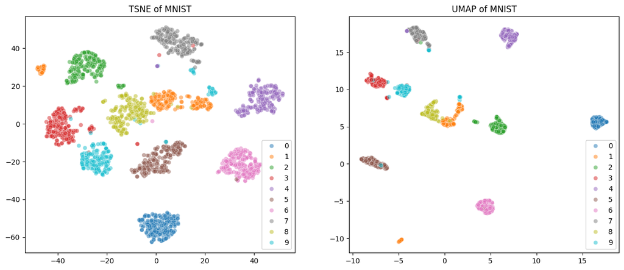

```python
fig, axs = plt.subplots(1, 2, figsize = (15, 6))
ax = axs[0]
# plt.scatter(embedding_tsne[:, 0], embedding_tsne[:, 1], c=labels, cmap='Spectral', s=5, ax=ax)
sns.scatterplot(x=embedding_tsne[:, 0], y=embedding_tsne[:, 1], hue=labels, palette='tab10', alpha=0.5, ax=ax)
ax.set_title("TSNE of MNIST")
ax = axs[1]
sns.scatterplot(x=embedding_umap[:, 0], y=embedding_umap[:, 1], hue=labels, palette='tab10', alpha=0.5, ax=ax)
ax.set_title("UMAP of MNIST");
```

## Vectors Computation

```python
df_a, _, _ = download_and_process_dataframes(include_contexts=False, include_labels=False, include_meshes=True)
```

We take a subset of it to reduce computational complexity (taking the whole dataset would be unfeasible):

```python
N = 10000
sampled_idxs = df_a.index.to_series().sample(n=N, replace=False, random_state=SEED)
```

```python
# X = df_a["question"] + " " + df_a["context"]
X = df_a["context"]
X = X.rename("input")
X = X.loc[sampled_idxs]
```

```python
nltk.download("punkt_tab")
os.environ["WANDB_DISABLED"] = "true"
```

Let's consider the following vectorizers:

1. **TF-IDF**
2. **ST** (Sentence Transformer)
3. **ST-FT** (Sentence Transformer fine-tuned on our dataset).

```python
vectorizer_TFIDF = TfidfVectorizer(max_df=0.8, min_df=5, stop_words='english')
# vectorizer_ST = SentenceTransformer("bert-base-uncased").to(DEVICE)
vectorizer_ST = SentenceTransformer("all-MiniLM-L6-v2").to(DEVICE)
vectorizer_ST_FT = SentenceTransformer("all-MiniLM-L6-v2").to(DEVICE)
```

[output not shown]

The Sentence Transformer if fine-tuning as a **denoising auto-encoder**, a self-supervised technique in which the model attempts to reconstruct the textual input after it has been corrupted with some grammatical noise.

```python
from sentence_transformers import SentenceTransformer, LoggingHandler
from sentence_transformers import models, util, datasets, evaluation, losses
from torch.utils.data import DataLoader

train_dataset = datasets.DenoisingAutoEncoderDataset(X.to_list())

train_dataloader = DataLoader(train_dataset, batch_size=8, shuffle=True)

train_loss = losses.DenoisingAutoEncoderLoss(
    vectorizer_ST_FT, tie_encoder_decoder=True
)

vectorizer_ST_FT.fit(
    train_objectives=[(train_dataloader, train_loss)],
    epochs=10,
    weight_decay=0,
    scheduler="constantlr",
    optimizer_params={"lr": 3e-5},
    show_progress_bar=True,
)

vectorizer_ST_FT.save("output/tsdae-model")
```

[output not shown]

```
We strongly recommend passing in an `attention_mask` since your input_ids may be padded. See https://huggingface.co/docs/transformers/troubleshooting#incorrect-output-when-padding-tokens-arent-masked.
```

[12500/12500 13:02, Epoch 10/10]

| Step | Training Loss |
| --- | --- |
| 500 | 6.038500 |
| 1000 | 4.202200 |
| 1500 | 3.569700 |
| 2000 | 3.211300 |
| 2500 | 2.919600 |
| 3000 | 2.691500 |
| 3500 | 2.570200 |
| 4000 | 2.435400 |
| 4500 | 2.310100 |
| 5000 | 2.270900 |
| 5500 | 2.108100 |
| 6000 | 2.104700 |
| 6500 | 1.982700 |
| 7000 | 1.934600 |
| 7500 | 1.931500 |
| 8000 | 1.800500 |
| 8500 | 1.795500 |
| 9000 | 1.733300 |
| 9500 | 1.677800 |
| 10000 | 1.688500 |
| 10500 | 1.569200 |
| 11000 | 1.589100 |
| 11500 | 1.524300 |
| 12000 | 1.485400 |
| 12500 | 1.499200 |

Let's extract the vocabularies building the vector spaces:

```python
vectorizer_TFIDF.fit(X)
vocab_TFIDF = vectorizer_TFIDF.get_feature_names_out()
print(f"[TF-IDF] Length of the vocabulary: {len(vocab_TFIDF)}")
```

```
[TF-IDF] Length of the vocabulary: 4049
```

```python
vocab_ST = list(vectorizer_ST._first_module().tokenizer.get_vocab().keys())
print(f"[TF-IDF] Length of the vocabulary: {len(vocab_ST)}")
```

```
[TF-IDF] Length of the vocabulary: 30522
```

```python
vocab_ST_FT = list(vectorizer_ST_FT._first_module().tokenizer.get_vocab().keys())
print(f"[TF-IDF] Length of the vocabulary: {len(vocab_ST_FT)}")
```

```
[TF-IDF] Length of the vocabulary: 30522
```

Then, we compute the vector representation of our inputs:

```python
X_TFIDF = vectorizer_TFIDF.transform(X)
X_ST = vectorizer_ST.encode(X.values)
X_ST_FT = vectorizer_ST_FT.encode(X.values)
```

As an example, let's see the most discriminative words in the first input according to TF-IDF:

```python
pd.DataFrame(sorted([(vocab_TFIDF[j], X_TFIDF[0, j].item()) for j in X_TFIDF[0].nonzero()[1]], key=lambda x: -x[1]), columns=["word", "value"])
```

|  | word | value |
| --- | --- | --- |
| 0 | kidney | 0.347626 |
| 1 | harvesting | 0.304712 |
| 2 | nephrectomy | 0.278650 |
| 3 | dopamine | 0.250235 |
| 4 | living | 0.250235 |
| 5 | intraoperative | 0.247957 |
| 6 | donors | 0.246508 |
| 7 | creatinine | 0.240568 |
| 8 | filtration | 0.240568 |
| 9 | glomerular | 0.239959 |
| 10 | period | 0.217142 |
| 11 | organ | 0.210562 |
| 12 | postoperative | 0.183082 |
| 13 | care | 0.175936 |
| 14 | transplantation | 0.175335 |
| 15 | tissue | 0.172458 |
| 16 | rate | 0.168448 |
| 17 | retrospective | 0.138768 |
| 18 | studies | 0.090183 |
| 19 | middle | 0.081541 |
| 20 | aged | 0.078328 |
| 21 | humans | 0.053459 |

## Dimensionality Reduction:

First, we find the low-rank SVD approximation of the embeddings to reduce the computational load for UMAP.

```python
tsvd = TruncatedSVD(n_components=10)
tsvd_TFIDF = tsvd.fit_transform(X_TFIDF)
tsvd_ST = tsvd.fit_transform(X_ST)
tsvd_ST_FT = tsvd.fit_transform(X_ST_FT)
```

Then, we perform manifold dimensionality reduction with UMAP:

```python
umap = UMAP(n_components=2, random_state=SEED)
umap_TFIDF = umap.fit_transform(tsvd_TFIDF)
umap_ST = umap.fit_transform(tsvd_ST)
umap_ST_FT = umap.fit_transform(tsvd_ST_FT)
```

## K-Means

```python
def kmeans_range(k_range, y, name):

    k_to_results = {}

    print(f"<=== [{name}] ===>")

    for k in k_range:

        print(f"K-Means with k = {k}", end="")

        t0 = time()
        kmeans = KMeans(n_clusters=k, n_init=10, random_state=SEED)
        kmeans.fit(y)

        silhoutte_score = silhouette_score(y[::10], kmeans.labels_[::10])
        k_to_results[k] = (kmeans, silhoutte_score)

        t1 = time()

        print(f" -> Done! [{round(t1 - t0, 2)} s]")
        print(f"Silhouette Score = {silhoutte_score:.5f}, WSS = {kmeans.inertia_}\n")

    return k_to_results
```

```python
k_to_results_TFIDF = kmeans_range(range(2, 21), X_TFIDF, 'TF-IDF')
k_to_results_ST = kmeans_range(range(2, 21), X_ST, 'ST')
k_to_results_ST_FT = kmeans_range(range(2, 21), X_ST_FT, 'ST_FT')
```

```
<=== [TF-IDF] ===>
K-Means with k = 2 -> Done! [0.19 s]
Silhouette Score = 0.01786, WSS = 9013.175900338476

K-Means with k = 3 -> Done! [0.36 s]
Silhouette Score = 0.01280, WSS = 8940.699701564457

K-Means with k = 4 -> Done! [0.57 s]
Silhouette Score = 0.01200, WSS = 8880.12341724429

K-Means with k = 5 -> Done! [0.58 s]
Silhouette Score = 0.01404, WSS = 8823.69683801761

K-Means with k = 6 -> Done! [0.8 s]
Silhouette Score = 0.01462, WSS = 8780.882106192119

K-Means with k = 7 -> Done! [1.04 s]
Silhouette Score = 0.01412, WSS = 8751.297804565882

K-Means with k = 8 -> Done! [1.25 s]
Silhouette Score = 0.01439, WSS = 8708.230028033124

K-Means with k = 9 -> Done! [1.33 s]
Silhouette Score = 0.01254, WSS = 8672.51251111436

K-Means with k = 10 -> Done! [2.38 s]
Silhouette Score = 0.00780, WSS = 8665.811207257662

K-Means with k = 11 -> Done! [2.09 s]
Silhouette Score = 0.01415, WSS = 8618.822301413802

K-Means with k = 12 -> Done! [1.56 s]
Silhouette Score = 0.01143, WSS = 8591.507535476132

K-Means with k = 13 -> Done! [1.76 s]
Silhouette Score = 0.01243, WSS = 8576.86748090588

K-Means with k = 14 -> Done! [2.08 s]
Silhouette Score = 0.01408, WSS = 8557.625806280485

```

[output cut: 118 more lines]

```

K-Means with k = 16 -> Done! [5.32 s]
Silhouette Score = 0.13546, WSS = 2465.940185546875

K-Means with k = 17 -> Done! [7.45 s]
Silhouette Score = 0.12337, WSS = 2437.62744140625

K-Means with k = 18 -> Done! [5.23 s]
Silhouette Score = 0.12597, WSS = 2406.284912109375

K-Means with k = 19 -> Done! [7.1 s]
Silhouette Score = 0.12299, WSS = 2379.978515625

K-Means with k = 20 -> Done! [6.13 s]
Silhouette Score = 0.12222, WSS = 2353.733154296875
```

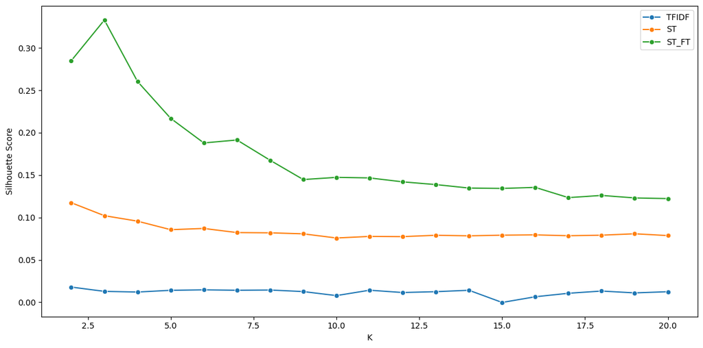

```python
plt.figure(figsize=(12, 6))
sns.lineplot(x=list(k_to_results_TFIDF.keys()), y=[d[1][1] for d in k_to_results_TFIDF.items()], marker="o", label="TFIDF")
sns.lineplot(x=list(k_to_results_ST.keys()), y=[d[1][1] for d in k_to_results_ST.items()], marker="o", label="ST")
sns.lineplot(x=list(k_to_results_ST_FT.keys()), y=[d[1][1] for d in k_to_results_ST_FT.items()], marker="o", label="ST_FT")
plt.xlabel('K')
plt.legend()
plt.ylabel('Silhouette Score')
plt.tight_layout()
```

Now, we select for best `k` for each vectorial representation:

```python
best_setting_TFIDF = max(k_to_results_TFIDF.items(), key=lambda d: d[1][1])
best_setting_ST = max(k_to_results_ST.items(), key=lambda d: d[1][1])
best_setting_ST_FT = max(k_to_results_ST_FT.items(), key=lambda d: d[1][1])
print(f"Best TF-IDF settings: {best_setting_TFIDF}")
print(f"Best ST settings: {best_setting_ST}")
print(f"Best ST_FT settings: {best_setting_ST_FT}")
```

```
Best TF-IDF settings: (2, (KMeans(n_clusters=2, n_init=10, random_state=42), np.float64(0.017855637266341588)))
Best ST settings: (2, (KMeans(n_clusters=2, n_init=10, random_state=42), np.float32(0.11737754)))
Best ST_FT settings: (3, (KMeans(n_clusters=3, n_init=10, random_state=42), np.float32(0.3328486)))
```

Let's predict the cluster for the data points:

```python
label_kmeans_TFIDF = best_setting_TFIDF[1][0].predict(X_TFIDF)
label_kmeans_ST = best_setting_ST[1][0].predict(X_ST)
label_kmeans_ST_FT = best_setting_ST_FT[1][0].predict(X_ST_FT)
```

Let's compute the **medoids** for each cluster in each setting:

```python
def compute_medoid(data_2d, labels):
    medoid_indices = []
    for label in np.unique(labels):
        cluster_mask = labels == label
        cluster_points = data_2d[cluster_mask]
        # Pairwise distances within cluster
        distances = np.sum(np.linalg.norm(cluster_points[:, None] - cluster_points[None, :], axis=2), axis=1)
        # Index relative to the whole dataset
        medoid_index = np.where(cluster_mask)[0][np.argmin(distances)]
        medoid_indices.append(medoid_index)
    medoids = data_2d[medoid_indices]
    return medoids
```

```python
medoids_TFIDF = compute_medoid(umap_TFIDF, label_kmeans_TFIDF)
medoids_ST = compute_medoid(umap_ST, label_kmeans_ST)
medoids_ST_FT = compute_medoid(umap_ST_FT, label_kmeans_ST_FT)
```

Finally, we plot the results:

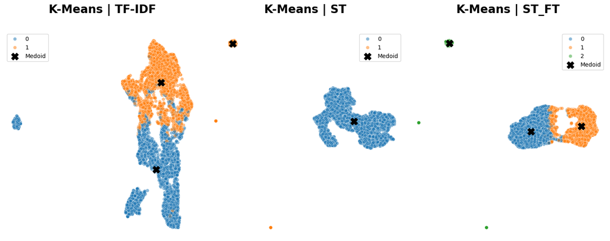

```python
fig, axs = plt.subplots(1, 3, figsize = (15, 6))

ax = axs[0]
sns.scatterplot(x=umap_TFIDF[:, 0], y=umap_TFIDF[:, 1], hue=label_kmeans_TFIDF, palette='tab10', alpha=0.5, ax=ax)
ax.scatter(medoids_TFIDF[:, 0], medoids_TFIDF[:, 1], c='black', s=150, marker='X', label='Medoid')
ax.set_title('K-Means | TF-IDF', fontweight='bold', fontsize=20, pad=32)
ax.legend()
ax.axis('off')

ax = axs[1]
sns.scatterplot(x=umap_ST[:, 0], y=umap_ST[:, 1], hue=label_kmeans_ST, palette='tab10', alpha=0.5, ax=ax)
ax.scatter(medoids_ST[:, 0], medoids_ST[:, 1], c='black', s=150, marker='X', label='Medoid')
ax.set_title('K-Means | ST', fontweight='bold', fontsize=20, pad=32)
ax.legend()
ax.axis('off')

ax = axs[2]
sns.scatterplot(x=umap_ST_FT[:, 0], y=umap_ST_FT[:, 1], hue=label_kmeans_ST_FT, palette='tab10', alpha=0.5, ax=ax)
ax.scatter(medoids_ST_FT[:, 0], medoids_ST_FT[:, 1], c='black', s=150, marker='X', label='Medoid')
ax.set_title('K-Means | ST_FT', fontweight='bold', fontsize=20, pad=32)
ax.legend()
ax.axis('off')

plt.tight_layout()
```

We selected `ST_FT` representations $k=3$, achieving a silhouette score $s = 0.3328486$.

## DB-SCAN

```python
from sklearn.metrics.pairwise import cosine_distances
from sklearn.preprocessing import normalize
```

```python
def fit_dbscan(X, name, eps=None, min_samples=None):

    print(f"<=== [{name}] ===>")

    t0 = time()
    if eps is not None and min_samples is not None:
        dbscan = DBSCAN(eps=eps, min_samples=min_samples)
    else:
        dbscan = DBSCAN()

    dbscan.fit(X)
    unique_labels, counts = np.unique(dbscan.labels_, return_counts=True)

    print(f"Number of clusters: {len(unique_labels)-1}")
    print(f"Number of noise points: {counts[0]}")
    print(f"Average cluster size: {np.mean(counts[1:])}")
    print(f"Std cluster size: {np.std(counts[1:])}")

    silhoutte_score = silhouette_score(X[::10], dbscan.labels_[::10])
    print(f"Silhouette Score = {silhoutte_score:.5f}\n")

    t1 = time()

    return dbscan# , silhoutte_score
```

```python
dbscan_TFIDF = fit_dbscan(X_TFIDF, 'TF-IDF', eps=1.0, min_samples=3)
```

```
<=== [TF-IDF] ===>
Number of clusters: 5
Number of noise points: 1866
Average cluster size: 1626.8
Std cluster size: 3247.100023097533
Silhouette Score = 0.01106
```

```python
dbscan_ST = fit_dbscan(X_ST, 'ST', 1.0, 2)
```

```
<=== [ST] ===>
Number of clusters: 8
Number of noise points: 93
Average cluster size: 1238.375
Std cluster size: 3066.0175283867834
Silhouette Score = 0.07822
```

```python
dbscan_ST_FT = fit_dbscan(X_ST_FT, 'ST_FT', 0.85, 4)
```

```
<=== [ST_FT] ===>
Number of clusters: 2
Number of noise points: 8
Average cluster size: 4996.0
Std cluster size: 4438.0
Silhouette Score = 0.32256
```

```python
label_dbscan_TFIDF = dbscan_TFIDF.labels_
label_dbscan_ST = dbscan_ST.labels_
label_dbscan_ST_FT = dbscan_ST_FT.labels_
```

Finally, we plot the DB-SCAN results:

[figure not shown]

```python
fig, axs = plt.subplots(1, 3, figsize = (15, 6))

ax = axs[0]
sns.scatterplot(x=umap_TFIDF[:, 0], y=umap_TFIDF[:, 1], hue=label_dbscan_TFIDF, palette='tab10', alpha=0.5, ax=ax)
ax.set_title('DB-SCAN | TF-IDF', fontweight='bold', fontsize=20, pad=32)
ax.axis('off')
ax.legend_.remove()

ax = axs[1]
sns.scatterplot(x=umap_ST[:, 0], y=umap_ST[:, 1], hue=label_dbscan_ST, palette='tab10', alpha=0.5, ax=ax)
ax.set_title('DB-SCAN | ST', fontweight='bold', fontsize=20, pad=32)
ax.axis('off')
ax.legend_.remove()

ax = axs[2]
sns.scatterplot(x=umap_ST_FT[:, 0], y=umap_ST_FT[:, 1], hue=label_dbscan_ST_FT, palette='tab10', alpha=0.5, ax=ax)
ax.set_title('DB-SCAN | ST', fontweight='bold', fontsize=20, pad=32)
ax.axis('off')
ax.legend_.remove()

plt.tight_layout()
```

Ultimately, `DBSCAN` failed to provide informative solutions in all tested cases, it struggles with capturing interesting patterns and clusters.

## Clustering Evaluation

As a result of the validation phase, we selected `k-means` with $k = 3$. Let's perform some further evaluation!

```python
meshes_vocab = np.array(list(set(split_and_clean_docs(list(X), remove_stopwords=True))))
meshes_vocab.shape
```

```
(9836,)
```

```python
vectorised_vocab = vectorizer_ST_FT.encode(meshes_vocab)
vectorised_vocab.shape
```

```
(9836, 384)
```

### Intrinsic

Let's inspect the cluster:

```python
l2_distance = lambda v, w: np.linalg.norm(v - w)
dot_product_distance = lambda v, w: -np.dot(v, w)
cosine_distance = lambda v, w: dot_product_distance(v, w) / (np.linalg.norm(v) * np.linalg.norm(w))
```

```python
kmeans = best_setting_ST_FT[1][0]
_, cluster_counts = np.unique(label_kmeans_ST_FT, return_counts=True)

for i, centroid in enumerate(kmeans.cluster_centers_):
    display(Markdown(f"#Cluster n. {i}:"))
    print(f"It contains {cluster_counts[i]} documents.")
    print(f"- - -")
    display(Markdown(f"**Most similar words of the meshes vocabulary**:"))
    most_similar_words_index = np.argsort([cosine_distance(centroid, word) for word in vectorised_vocab]) # ascending order
    print(np.array(meshes_vocab)[most_similar_words_index[:20]])
    print(f"- - -")
    display(Markdown(f"**Most similar question-context**:"))
    most_similar_doc_index = np.argmin([cosine_distance(centroid, doc) for doc in X_ST_FT[label_kmeans_ST_FT == i]]) # ascending order
    most_similar_doc = df_a.loc[X.index[most_similar_doc_index]]
    print(f"Question: {most_similar_doc.loc['question']}")
    print(f"Context: {most_similar_doc.loc['context']}")
    display(Markdown(f"---"))
```

Cluster n. 0:

```
It contains 5073 documents.
- - -
```

**Most similar words of the meshes vocabulary**:

```
['salaries' 'questionnaires' 'timetotreatment' 'geriatrics' 'visits'
 'department' 'inpatients' 'socioeconomic' 'income' 'obstetrics' 'career'
 'competency' 'epidemiology' 'risktaking' 'review' 'emigration' 'status'
 'halflife' 'retreatment' 'postpartum']
- - -
```

**Most similar question-context**:

```
Question: Is central obesity important but not essential component of the metabolic syndrome for predicting diabetes mellitus in a hypertensive familybased cohort  Results from the Stanford Asiapacific program for hypertension and insulin resistance  SAPPHIRe  Taiwan followup study
Context:  Adult Asian Continental Ancestry Group Diabetes Mellitus Female FollowUp Studies Humans Hypertension Incidence Insulin Resistance Male Metabolic Syndrome Middle Aged Obesity Abdominal Pedigree Prognosis Proportional Hazards Models Risk Assessment Risk Factors Taiwan Time Factors
```

Cluster n. 1:

```
It contains 4366 documents.
- - -
```

**Most similar words of the meshes vocabulary**:

```
['34dichloronmethyln21pyrrolidinylcyclohexylbenzeneacetamide'
 'calciumcalmodulindependent'
 'alphaamino3hydroxy5methyl4isoxazolepropionic'
 '1alkyl2acetylglycerophosphocholine'
 '15isoquinolinesulfonyl2methylpiperazine'
 '1methyl4phenyl1236tetrahydropyridine'
 'dichlororibofuranosylbenzimidazole' 'phenoxyacetates'
 'thioredoxindisulfide' 'glycosylphosphatidylinositols'
 '14dihydro26dimethyl5nitro42trifluoromethylphenyl'
 'polytetrafluoroethylene' 'cytosine5methyltransferase'
 'betafructofuranosidase' 'betacyclodextrins'
 'acetylmuramylalanylisoglutamine' 'oligodeoxyribonucleotides'
 'nethylmaleimidesensitive' 'gammacyclodextrins' 'schizosaccharomyces']
- - -
```

**Most similar question-context**:

```
Question: Is progression of early carotid atherosclerosis only temporarily reduced after antibiotic treatment of Chlamydia pneumoniae seropositivity
Context:  Aged Antibodies Bacterial Brain Ischemia Carotid Artery Diseases Carotid Artery Common Chlamydophila Infections Chlamydophila pneumoniae Disease Progression Female FollowUp Studies Humans Life Tables Male Middle Aged Myocardial Infarction Proportional Hazards Models Prospective Studies Rec…
```

Cluster n. 2:

```
It contains 561 documents.
- - -
```

**Most similar words of the meshes vocabulary**:

```
['right' 'second' '1' 'bn' 'product' 'first' 'us' 'x' 'great' 'new'
 'highly' 'vs' 'third' 'b2' 'part' 'ii' 'sick' 'fc' 'stunning' '2']
- - -
```

**Most similar question-context**:

```
Question: Does acetate transiently inhibit myocardial contraction by increasing mitochondrial calcium uptake
Context:  Animals Calcium Male Mice Mice Inbred C57BL Mitochondria Myocardial Contraction Sodium Acetate
```

The clusters are not that interesting:

- `cluster_0` comprises regular words from a medical domain.
- `cluster_1` contains specific chemical terms.
- `cluster_2` comprises uninformative, uninteresting words.

### Extrinsic

Our dataset has labels, hence we can employ **extrinsic metrics** as well. However, we do not expect these metrics to provide interesting results since the classes rely on logical, linguistic information which vectorial representations struggle with.

Let's compute the most frequent final decision for each cluster:

We take the final_decision from the dataset for each selected indexes

```python
fin_dec = df_a.loc[sampled_idxs]['final_decision']
```

Then we create a dataframe containing the final_decision, and the result of the clustering

```python
temp = fin_dec.copy()
```

```python
df_label_dbscan_st_ft = pd.Series(label_dbscan_ST_FT, index=sampled_idxs).to_frame()
df_label_dbscan_st_ft.columns = ['dbscan_st_ft']

df_label_dbscan_st = pd.Series(label_dbscan_ST, index=sampled_idxs).to_frame()
df_label_dbscan_st.columns = ['dbscan_st']

df_label_dbscan_tfidf = pd.Series(label_dbscan_TFIDF, index=sampled_idxs).to_frame()
df_label_dbscan_tfidf.columns = ['dbscan_tfidf']

df_label_kmeans_st_ft = pd.Series(label_kmeans_ST_FT, index=sampled_idxs).to_frame()
df_label_kmeans_st_ft.columns = ['kmeans_st_ft']

df_label_kmeans_st = pd.Series(label_kmeans_ST, index=sampled_idxs).to_frame()
df_label_kmeans_st.columns = ['kmeans_st']

df_label_kmeans_tfidf = pd.Series(label_kmeans_TFIDF, index=sampled_idxs).to_frame()
df_label_kmeans_tfidf.columns = ['kmeans_tfidf']
```

```python
temp1 = pd.concat([temp, df_label_dbscan_st, df_label_dbscan_st_ft, df_label_dbscan_tfidf, df_label_kmeans_st, df_label_kmeans_st_ft, df_label_kmeans_tfidf], axis=1)
```

We delete the rows with -1 on the dbscan results

```python
temp1 = temp1[~((temp1['dbscan_tfidf'] == -1) | (temp1['dbscan_st'] == -1) | (temp1['dbscan_st_ft'] == -1))]
```

```python
# dbscan: most common final decision per cluster

for i, col in enumerate(temp1.columns):
  if(col != 'final_decision'):
    print(f'{col}:')
    for c in temp1[col].unique():
      t = (temp1[temp1['dbscan_st'] == c]['final_decision'].value_counts(normalize=True)).to_dict()
      print(f'\tcluster: {c} \n\t\tfinal decision percentage: {t}')
    print('\n')
```

```
dbscan_st:
	cluster: 0
		final decision percentage: {'yes': 0.9251537022186581, 'no': 0.07484629778134189}
	cluster: 1
		final decision percentage: {'yes': 0.9229390681003584, 'no': 0.07706093189964158}
	cluster: 2
		final decision percentage: {'yes': 1.0}
	cluster: 3
		final decision percentage: {'yes': 1.0}
	cluster: 4
		final decision percentage: {'yes': 1.0}
	cluster: 5
		final decision percentage: {'yes': 1.0}
	cluster: 6
		final decision percentage: {'yes': 1.0}
	cluster: 7
		final decision percentage: {'yes': 1.0}


dbscan_st_ft:
	cluster: 0
		final decision percentage: {'yes': 0.9251537022186581, 'no': 0.07484629778134189}
	cluster: 1
		final decision percentage: {'yes': 0.9229390681003584, 'no': 0.07706093189964158}


dbscan_tfidf:
	cluster: 0
		final decision percentage: {'yes': 0.9251537022186581, 'no': 0.07484629778134189}
	cluster: 2
		final decision percentage: {'yes': 1.0}
	cluster: 1
		final decision percentage: {'yes': 0.9229390681003584, 'no': 0.07706093189964158}
	cluster: 3
		final decision percentage: {'yes': 1.0}
	cluster: 4
		final decision percentage: {'yes': 1.0}


kmeans_st:
	cluster: 0
		final decision percentage: {'yes': 0.9251537022186581, 'no': 0.07484629778134189}
	cluster: 1
		final decision percentage: {'yes': 0.9229390681003584, 'no': 0.07706093189964158}


kmeans_st_ft:
	cluster: 0
		final decision percentage: {'yes': 0.9251537022186581, 'no': 0.07484629778134189}
	cluster: 1
		final decision percentage: {'yes': 0.9229390681003584, 'no': 0.07706093189964158}
	cluster: 2
		final decision percentage: {'yes': 1.0}


kmeans_tfidf:
	cluster: 1
		final decision percentage: {'yes': 0.9229390681003584, 'no': 0.07706093189964158}
	cluster: 0
		final decision percentage: {'yes': 0.9251537022186581, 'no': 0.07484629778134189}
```

Now, let's compute some actual **extrinsic metrics**:

- Adjusted Rand Index (`ARI`).
- Normalized Mutual Info (`NMI`).
- Fowlkes-Mallows Index (`FMI`).

```python
from sklearn.metrics import adjusted_rand_score, normalized_mutual_info_score, fowlkes_mallows_score
```

```python
# encoding final_decision using LabelEncoder
from sklearn.preprocessing import LabelEncoder

le = LabelEncoder()

temp1['final_decision'] = le.fit_transform(temp1['final_decision'])
```

**Adjusted Rand Index**

It is useful to see how consistently the groupings are between the clustering and the ground truth:

```python
ari_dbscan_st_ft = adjusted_rand_score(temp1['final_decision'], temp1['dbscan_st_ft'])
ari_dbscan_st = adjusted_rand_score(temp1['final_decision'], temp1['dbscan_st'])
ari_dbscan_tfidf = adjusted_rand_score(temp1['final_decision'], temp1['dbscan_tfidf'])

ari_kmeans_st_ft = adjusted_rand_score(temp1['final_decision'], temp1['kmeans_st_ft'])
ari_kmeans_st = adjusted_rand_score(temp1['final_decision'], temp1['kmeans_st'])
ari_kmeans_tfidf = adjusted_rand_score(temp1['final_decision'], temp1['kmeans_tfidf'])
```

**Normalized Mutual Info**

Compute the information overlap between clustering and true label (final_decision):

```python
nmi_dscan_st_ft = normalized_mutual_info_score(temp1['final_decision'], temp1['dbscan_st_ft'])
nmi_dscan_st = normalized_mutual_info_score(temp1['final_decision'], temp1['dbscan_st'])
nmi_dscan_tfidf = normalized_mutual_info_score(temp1['final_decision'], temp1['dbscan_tfidf'])

nmi_kmeans_st_ft = normalized_mutual_info_score(temp1['final_decision'], temp1['kmeans_st_ft'])
nmi_kmeans_st = normalized_mutual_info_score(temp1['final_decision'], temp1['kmeans_st'])
nmi_kmeans_tfidf = normalized_mutual_info_score(temp1['final_decision'], temp1['kmeans_tfidf'])
```

**Fowlkes-Mallows Index**

Compare true and predicted label in a binary classification way:

```python
fmi_dscan_st_ft = fowlkes_mallows_score(temp1['final_decision'], temp1['dbscan_st_ft'])
fmi_dscan_st = fowlkes_mallows_score(temp1['final_decision'], temp1['dbscan_st'])
fmi_dscan_tfidf = fowlkes_mallows_score(temp1['final_decision'], temp1['dbscan_tfidf'])

fmi_kmeans_st_ft = fowlkes_mallows_score(temp1['final_decision'], temp1['kmeans_st_ft'])
fmi_kmeans_st = fowlkes_mallows_score(temp1['final_decision'], temp1['kmeans_st'])
fmi_kmeans_tfidf = fowlkes_mallows_score(temp1['final_decision'], temp1['kmeans_tfidf'])
```

```python
print(f'Adjusted Rand Index:\n\tDBSCAN\n\t\tST_FT: {ari_dbscan_st_ft:.4f}\n\t\tST: {ari_dbscan_st:.4f}\n\t\tTFIDF: {ari_dbscan_tfidf:.4f}\n\tKMEANS\n\t\tST_FT: {ari_kmeans_st_ft:.4f}\n\t\tST: {ari_kmeans_st:.4f}\n\t\tTFIDF: {ari_kmeans_tfidf:.4f}')
print(f'\nNormalized Mutual Info:\n\tDBSCAN\n\t\tST_FT: {nmi_dscan_st_ft:.4f}\n\t\tST: {nmi_dscan_st:.4f}\n\t\tTFIDF: {nmi_dscan_tfidf:.4f}\n\tKMEANS\n\t\tST_FT: {nmi_kmeans_st_ft:.4f}\n\t\tST: {nmi_kmeans_st:.4f}\n\t\tTFIDF: {nmi_kmeans_tfidf:.4f}')
print(f'\nFowlkes-Mallows Index:\n\tDBSCAN\n\t\tST_FT: {fmi_dscan_st_ft:.4f}\n\t\tST: {fmi_dscan_st:.4f}\n\t\tTFIDF: {fmi_dscan_tfidf:.4f}\n\tKMEANS\n\t\tST_FT: {fmi_kmeans_st_ft:.4f}\n\t\tST: {fmi_kmeans_st:.4f}\n\t\tTFIDF: {fmi_kmeans_tfidfz:.4f}')
```

[output not shown]

Let's perform some analyses:

- **DBSCAN**
  - `ARI`: Consistently extremely low, indicating performance very close to random agreement.
  - `NMI`: Extremely low scores across all feature sets, very little shared information.
  - `FMI`: Surprisingly high, especially for TFIDF. This is a critical discrepancy with ARI and NMI. It suggests DBSCAN might be excellent at identifying pairs of correctly clustered points.
- **K-MEANS**:
  - `ARI`: Also consistently very low. The negative score for ST_FT is particularly concerning, implying performance worse than random.
  - `NMI`: While still very low, marginally higher than DBSCAN's best.
  - `FMI`: More varied, but still with significant results.

Overall, both DBSCAN and K-Means performed poorly at clustering, essentially producing random results based on standard metrics. While the Fowlkes-Mallows Index was surprisingly high, it likely reflects only local, pairwise accuracy rather than a meaningful overall cluster structure. The main takeaway is that the current feature representations are insufficient.

# 3.0 Topic Modeling

After clustering, we perform **topic modeling** to the same subset of data (transformed in the same way). Thus, unlike before, we are able to express the data points as mixtures of non-exclusive clusters. For this task, we are going to employ **LDA** (Latent Dirichlet Allocation).

First, we split the data into a train and test set:

```python
documents_train, documents_test = train_test_split(X, test_size=0.4)
print('No. training docs:', len(documents_train))
print('No. testing docs:', len(documents_test))
```

```
No. training docs: 6000
No. testing docs: 4000
```

LDA is a probabilistic models which reasons on top of raw term counts (**BoW**), hence we are going to feed it documents encoded by `CountVectorizer`.

```python
vectorizer = CountVectorizer(stop_words='english', min_df=5, max_df=0.5)
vector_documents_train = vectorizer.fit_transform(documents_train)
```

```python
lda = LatentDirichletAllocation(n_components=30, verbose=1, learning_method='online', max_iter=30)
lda.fit(vector_documents_train)
```

```
iteration: 1 of max_iter: 30
iteration: 2 of max_iter: 30
iteration: 3 of max_iter: 30
iteration: 4 of max_iter: 30
iteration: 5 of max_iter: 30
iteration: 6 of max_iter: 30
iteration: 7 of max_iter: 30
iteration: 8 of max_iter: 30
iteration: 9 of max_iter: 30
iteration: 10 of max_iter: 30
iteration: 11 of max_iter: 30
iteration: 12 of max_iter: 30
iteration: 13 of max_iter: 30
iteration: 14 of max_iter: 30
iteration: 15 of max_iter: 30
iteration: 16 of max_iter: 30
iteration: 17 of max_iter: 30
iteration: 18 of max_iter: 30
iteration: 19 of max_iter: 30
iteration: 20 of max_iter: 30
iteration: 21 of max_iter: 30
iteration: 22 of max_iter: 30
iteration: 23 of max_iter: 30
iteration: 24 of max_iter: 30
iteration: 25 of max_iter: 30
iteration: 26 of max_iter: 30
iteration: 27 of max_iter: 30
iteration: 28 of max_iter: 30
iteration: 29 of max_iter: 30
iteration: 30 of max_iter: 30
```

```
LatentDirichletAllocation(learning_method='online', max_iter=30,
                          n_components=30, verbose=1)
```

Let's compute the perplexity on the test set to have an idea of the performance:

```python
vector_documents_test = vectorizer.transform(documents_test)
lda.perplexity(vector_documents_test)
```

```
np.float64(856.8892274010949)
```

For each topic, let's compute the most important words for each topic:

```python
for i in range(len(lda.components_)):
    sorted_terms = lda.components_[i].argsort()[::-1]
    concatenated_terms = '[' + ', '.join(vocab[i] for i in sorted_terms[:10]) + ']'
    print (f'Topic {i + 1}:\t', concatenated_terms)
```

```
Topic 1:	 [analysis, statistics, variance, dental, cognition, linear, disorders, nonparametric, aging, fluid]
Topic 2:	 [image, arthritis, computerassisted, joint, rheumatoid, processing, radiography, synovial, arthroplasty, interpretation]
Topic 3:	 [lung, pulmonary, respiratory, disease, chronic, volume, solutions, tract, allergens, obstructive]
Topic 4:	 [growth, factor, endothelial, vascular, antibodies, species, neovascularization, oxygen, monoclonal, reactive]
Topic 5:	 [rats, animals, spraguedawley, liver, drug, type, animal, agents, relationship, doseresponse]
Topic 6:	 [child, infant, pregnancy, preschool, adolescent, studies, newborn, adult, sleep, perception]
Topic 7:	 [gene, expression, proteins, rna, regulation, reaction, polymerase, chain, sequence, cell]
Topic 8:	 [genetic, polymorphism, disease, genotype, nucleotide, single, predisposition, staging, aged, group]
Topic 9:	 [aged, adult, middle, studies, young, 80, adolescent, health, prospective, care]
Topic 10:	 [regression, markers, testing, environment, pyrroles, lens, crystalline, ophthalmic, vitrectomy, phospholipases]
Topic 11:	 [cells, cell, techniques, antigens, cultured, tumor, necrosis, stem, receptors, factoralpha]
Topic 12:	 [disorders, motor, behavior, flow, longitudinal, disorder, spinal, depression, mental, activity]
Topic 13:	 [proteins, protein, cell, kinases, kinase, cells, signal, transduction, factor, protooncogene]
Topic 14:	 [neoplasms, cell, tumor, neoplasm, carcinoma, survival, line, antineoplastic, prognosis, neoplastic]
Topic 15:	 [stress, oxidative, skin, glutathione, wound, hypersensitivity, healing, antioxidants, products, diseases]
Topic 16:	 [body, mass, obesity, index, factors, weight, surveys, life, analysis, questionnaires]
Topic 17:	 [dna, neurotrophic, chlamydia, junctions, brainderived, tight, fragmentation, chromatin, polyadpribose, mucous]
Topic 18:	 [agents, drug, bacterial, infections, allocation, random, antiinflammatory, count, combination, interactions]
Topic 19:	 [muscle, bone, plant, tomography, xray, computed, skeletal, smooth, contraction, density]
Topic 20:	 [apnea, intubation, endoscopic, airway, polycystic, positive, obstructive, intratracheal, cholangiopancreatography, retrograde]
Topic 21:	 [tissue, dietary, adipose, hormones, supplements, phosphoproteins, cortex, tuberculosis, adrenal, progesterone]
Topic 22:	 [cholesterol, matrix, metalloproteinase, ldl, lipid, lymph, extracellular, triglycerides, lipoproteins, hdl]
Topic 23:	 [mice, animals, inbred, animal, disease, c57bl, models, knockout, cells, balb]
Topic 24:	 [inhibitors, curve, enzyme, metabolic, roc, area, aggregation, cytochrome, p450, glaucoma]
Topic 25:	 [pain, severity, patient, injuries, illness, index, topic, period, postoperative, hospital]
Topic 26:	 [outcome, treatment, studies, kidney, retrospective, surgical, transplantation, procedures, postoperative, survival]
Topic 27:	 [heart, imaging, brain, magnetic, resonance, myocardial, cardiac, sensitivity, specificity, ventricular]
Topic 28:	 [aged, studies, middle, factors, risk, adult, tests, analysis, cohort, prospective]
Topic 29:	 [psychological, learning, piperidines, pyrazoles, balance, muscles, postural, cannabinoid, maze, hippocampus]
Topic 30:	 [blood, oxide, nitric, vascular, animals, biological, synthase, endothelium, artery, retinal]
```

The algorithm finds some insightful info! E.g.:

- Topic n. 1 seems to aggregate terms semantically related to **statistics** ("analysis", "variance", "linear", ...).
- Topic n. 6 seems to aggregate terms related to **children** ("child", "infant", "newborn", ...).
- Topic n. 16 seems to aggregate terms related to **weight** ("body", "mass", "obesity", ...).

However, a more careful selection of the number of components might refine the results, since the topics tend to have some overlapping. Anyway, these results should be validated by experts of the field.

Moving on, each term is associated with a certain **importance** w.r.t. each topic. Let's plot, for every topic, the most important words (the ones just presented) along with their prevalence:

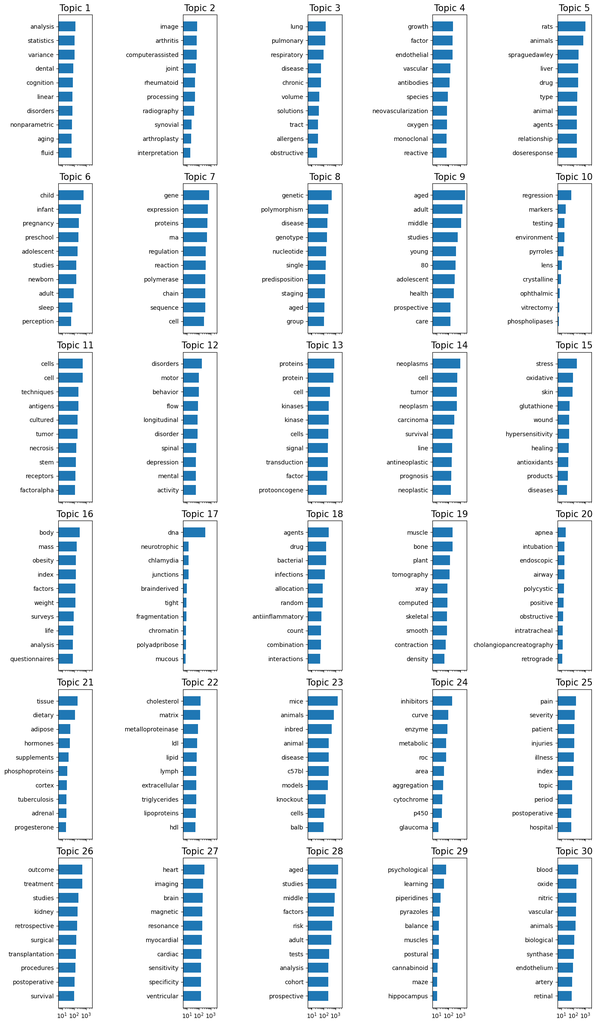

```python
num_words = 10
cols = 5
rows = int(len(lda.components_)/5)

fig, axes = plt.subplots(rows, cols, figsize=(14, 4 * rows), sharex=True)
axes = axes.flatten()
for topic_idx, topic in enumerate(lda.components_):
    top_terms_index = topic.argsort()[:-num_words - 1:-1]
    top_terms = [vocab[i] for i in top_terms_index]
    weights = topic[top_terms_index]
    ax = axes[topic_idx]
    ax.barh(top_terms, weights, height=0.7)
    ax.set_title(f'Topic {topic_idx +1}',fontdict={'fontsize': 15})
    ax.invert_yaxis()
    ax.set_xscale('log')

plt.subplots_adjust(top=0.90, bottom=0.05, wspace=0.90, hspace=0.3)
plt.tight_layout()
plt.show()
```

Now, let's sample a random document from the test set and display the LDA-transformed vector expressing the importance of each topic:

```python
doc = documents_test.iloc[3000]
print(doc)
```

```
 Adolescent Analysis of Variance Brachial Plexus Electric Stimulation Electromyography Evoked Potentials Motor Extremities Female Functional Laterality Humans Linear Models Male Motor Cortex Muscle Contraction Muscle Skeletal Reaction Time Resistance Training Transcranial Magnetic Stimulation Weight…
```

```python
doc_vec = vectorizer.transform([doc])[0]
topic_vec = lda.transform(doc_vec)[0]
topic_vec
```

```
array([0.10235441, 0.00104167, 0.00104167, 0.00104167, 0.00104167,
       0.05597459, 0.00104167, 0.00104167, 0.06096635, 0.00104167,
       0.03243233, 0.07082239, 0.00104167, 0.00104167, 0.00104167,
       0.04030145, 0.00104167, 0.00104167, 0.16357532, 0.00104167,
       0.00104167, 0.00104167, 0.00104167, 0.00104167, 0.06906912,
       0.00104167, 0.33122672, 0.052444  , 0.00104167, 0.00104167])
```

Some topics (e.g., the first, the 4th-but-last, ...) have more prevalence in the sampled document than others. Indeed, there are many zeros in the vector, which correspond to topics which have little influence on the document, since their words were not actually found in it.

Let's now present a more insightful visualisation, in which we display the most important topics (along with their terms), filtering out the one with less than 1% prevalence:

```python
sorted_topics = topic_vec.argsort()[::-1]
sorted_prevalence = sorted(topic_vec)[::-1]
```

```python
for i in range(10):
    if sorted_prevalence[i] < .01: break
    topic = sorted_topics[i]
    sorted_terms = np.flip(lda.components_[topic].argsort())
    print (f'{100 * sorted_prevalence[i]:.1f}% Topic {topic}: {" ".join(vocab[i] for i in sorted_terms[:10])}')
```

```
33.1% Topic 26: heart imaging brain magnetic resonance myocardial cardiac sensitivity specificity ventricular
16.4% Topic 18: muscle bone plant tomography xray computed skeletal smooth contraction density
10.2% Topic 0: analysis statistics variance dental cognition linear disorders nonparametric aging fluid
7.1% Topic 11: disorders motor behavior flow longitudinal disorder spinal depression mental activity
6.9% Topic 24: pain severity patient injuries illness index topic period postoperative hospital
6.1% Topic 8: aged adult middle studies young 80 adolescent health prospective care
5.6% Topic 5: child infant pregnancy preschool adolescent studies newborn adult sleep perception
5.2% Topic 27: aged studies middle factors risk adult tests analysis cohort prospective
4.0% Topic 15: body mass obesity index factors weight surveys life analysis questionnaires
3.2% Topic 10: cells cell techniques antigens cultured tumor necrosis stem receptors factoralpha
```

Just like we previously did in the *Clustering* section, we now visualize the LDA-transformed vector in a space of lower dimensionality.

To do so, we perform the dimensionality reduction with **UMAP** again, to project the 30-dimensional vector (the mixture-of-topics representation) to a 3-dimensional one.

```python
umap_embedding = UMAP(n_components=3, random_state=SEED).fit_transform(lda.transform(vector_documents_test))
```

```python
[x, y, z] = np.transpose(umap_embedding)
```

```python
import plotly.graph_objects as go
import numpy as np

# Create 3D data

# Create interactive 3D scatter plot
fig = go.Figure(data=[go.Scatter3d(
    x=x, y=y, z=z,
    mode='markers',
    marker=dict(size=3, color=z, colorscale='Viridis', opacity=0.8)
)])
fig.show()
```

[interactive chart not shown]

Each point in this 3D plot is a document, and (provided that UMAP succeded in its task), closer points are express by a similar mixture of topics (hence are semantically similar). To favour the visualisation, the color maps highlights the smooth transition of the data points from one topical representation to another.

It seems that most of the documents are gathered together in a ring of points, while a small cluster is clearly separated and distant from it. This conveys the fact that most of the documents have some similarity or shared structure (they might lie be a low-dimensional manifold, which we are trying to recover), while another set of documents has some very different and distinctive characteristics.